# Выполнение лабораторной работы №5

Настройка рабочей среды

Автор

принадлежность

Карпухин Клим

Российский университет дружбы народов

Дата публикации

2026-03-14

# Содержание

1. Информация о докладчике
2. Вводная часть и актуальность
3. Объект и предмет исследования
4. Научная новизна и практическая значимость
5. Цель, гипотеза и задачи
6. Материалы, методы и инструменты
7. Ход работы (этапы, скриншоты)
8. Результаты и анализ
9. Выводы

# Информация

## Докладчик

- **Карпухин Клим**
- Российский университет дружбы народов
- Email: 1032255580@rudn.ru
- Роли: студент (лабораторная работа по ОС/виртуализации)

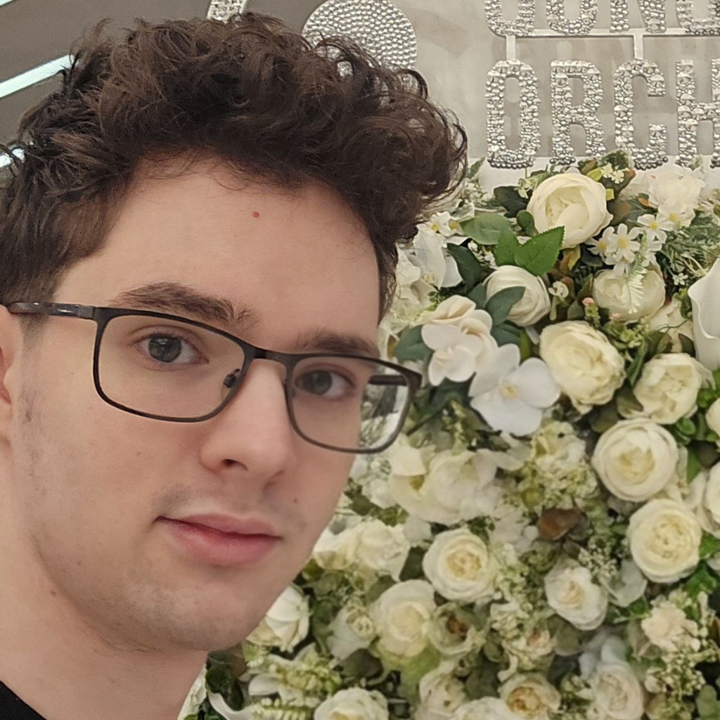

# Вводная часть

## Актуальность

- Современные специалисты ежедневно работают с множеством учётных записей и конфигурационных файлов. Безопасное хранение паролей и управление настройками рабочей среды — критически важные задачи.
- Инструменты pass (менеджер паролей) и chezmoi (управление dotfiles) позволяют решить эти задачи с использованием проверенных криптографических методов (GPG) и систем контроля версий (Git).
- Синхронизация паролей и конфигураций между несколькими машинами становится простой и надёжной, что особенно актуально для разработчиков и администраторов.

## Объект и предмет исследования

- **Объект:** процесс безопасного хранения учётных данных и управления конфигурационными файлами в Unix-подобных операционных системах.
- **Предмет:** менеджер паролей `pass`, его расширения (`gopass`, `browserpass`), система управления dotfiles `chezmoi`, а также технологии GPG и Git как основа для их работы.

# Научная новизна и практическая значимость

## Научная новизна

- Интеграция GPG-шифрования с файловой системой для организации иерархического хранилища паролей.
- Использование Git для версионирования и синхронизации зашифрованных данных без раскрытия их содержимого.
- Применение шаблонов (Go templates) в `chezmoi` для адаптации конфигураций под различные машины в рамках единого репозитория dotfiles.

## Практическая значимость работы

- Полученные навыки позволяют организовать единое безопасное хранилище паролей, доступное с любого устройства, и автоматически разворачивать рабочее окружение на новых машинах.
- Снижение риска потери или компрометации паролей за счёт шифрования и резервного копирования через Git.
- Ускорение настройки новых рабочих мест и упрощение поддержки существующих конфигураций.

# Цель, гипотеза и задачи

## Цель

Освоить работу с менеджером паролей `pass` и системой управления файлами конфигурации `chezmoi`. Получить навыки безопасного хранения паролей, синхронизации их через Git, а также управления конфигурационными файлами на нескольких машинах.

## Гипотеза

Применение `pass` и `chezmoi` позволит значительно повысить безопасность и воспроизводимость рабочей среды, упростив её перенос между устройствами.

## Задачи

- Установить и настроить менеджер паролей `pass` и его расширение `gopass`.
- Сгенерировать GPG-ключ и инициализировать хранилище паролей.
- Подключить удалённый Git-репозиторий для синхронизации хранилища.
- Установить браузерное расширение `browserpass` для удобного использования паролей.
- Установить `chezmoi` и создать собственный репозиторий dotfiles на основе шаблона.
- Протестировать управление конфигурацией на локальной машине и развернуть её на другой системе.

# Материалы и методы

## Материалы и методы

- **Инструменты:**
  - Менеджер паролей **pass** (стандартный менеджер паролей Unix).
  - Расширенная версия **gopass** (с дополнительными возможностями).
  - Криптографическая система **GPG** для шифрования паролей.
  - Система контроля версий **Git** и платформа **GitHub** для синхронизации.
  - Браузерное расширение **browserpass** для интеграции с браузером.
  - Инструмент управления dotfiles **chezmoi**.
  - Редактор и утилиты командной строки (установка шрифтов, бинарных файлов).

# Ход работы — установка и настройка pass

## Этап 1: Установка pass и gopass

- Установка менеджера паролей `pass` из репозитория.

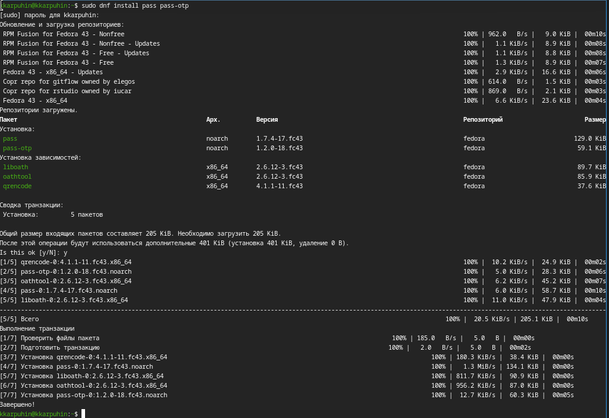

Рисунок 1: Установка pass

- Установка расширенной версии `gopass`.

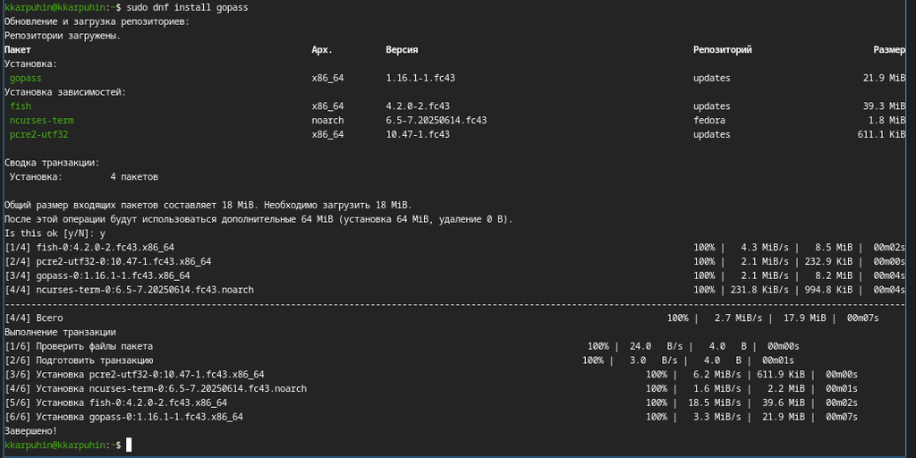

Рисунок 2: Установка gopass

## Этап 2: Настройка GPG и инициализация хранилища

- Просмотр существующих GPG-ключей.

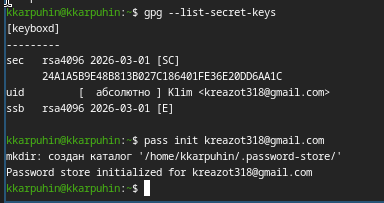

Рисунок 3: Просмотр ключей

- Инициализация хранилища паролей с использованием выбранного ключа.

## Этап 3: Синхронизация через Git

- Создание Git-структуры внутри хранилища.

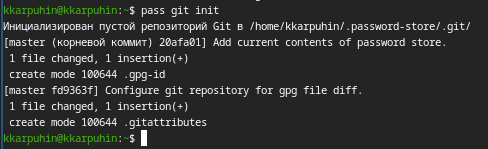

Рисунок 5: Создание структуры git

## Этап 4: Добавление пароля и настройка browserpass

- Добавление нового пароля в хранилище.

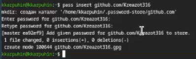

Рисунок 7: Добавление нового пароля

- Настройка интерфейса для взаимодействия с браузером (browserpass).

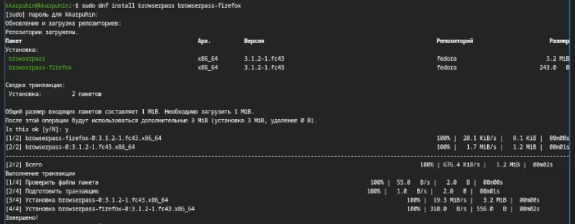

Рисунок 8: Настройка интерфейса для браузера

# Ход работы — установка и настройка chezmoi

## Этап 5: Установка chezmoi и создание репозитория dotfiles

- Установка дополнительного ПО (chezmoi, шрифты, бинарные файлы).

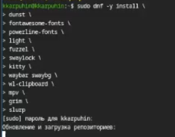

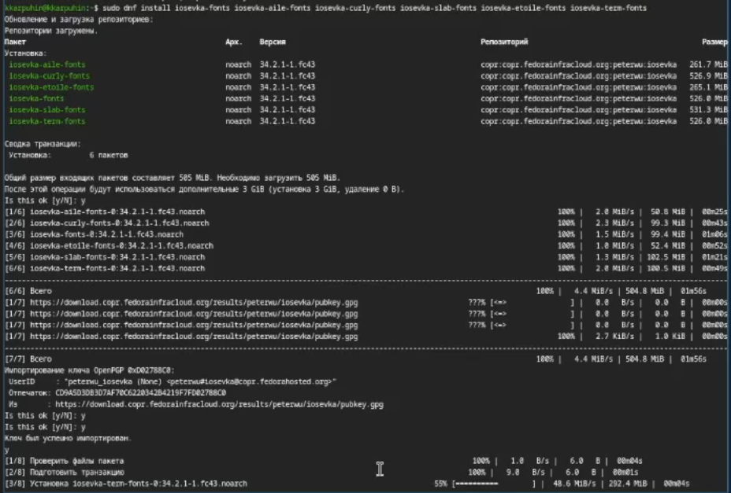

- Создание собственного репозитория dotfiles с помощью утилит chezmoi.

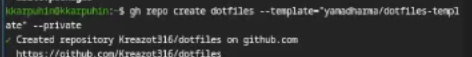

Рисунок 9: Создание репозитория с помощью утилит

## Этап 6: Подключение репозитория и работа на другой машине

- Подключение созданного репозитория к текущей системе.

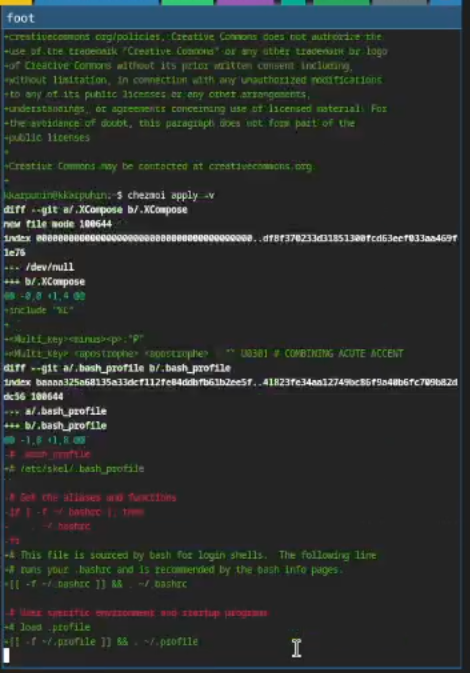

Рисунок 10: Подключение репозитория к системе

- На второй машине инициализация chezmoi с тем же репозиторием dotfiles.

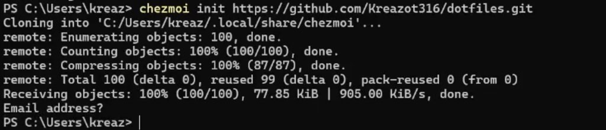

Рисунок 11: Инициализация chezmoi с репозиторием dotfiles

- Добавление параметров autoCommit и autoPush в конфигурацию для автоматической синхронизации.

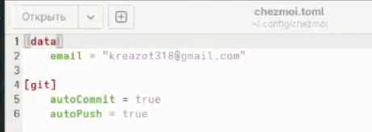

Рисунок 12: Добавление autoCommit и autoPush в конфигурацию

# Результаты и анализ

## Практическая значимость результатов

- Полученная инфраструктура обеспечивает высокий уровень безопасности учётных данных и лёгкость восстановления окружения при смене оборудования.
- Навыки работы с `chezmoi` позволяют эффективно поддерживать единообразие конфигураций в команде или на личных устройствах.
- Достигнутая автоматизация (autoCommit/autoPush) минимизирует ручные операции при изменении конфигураций.

# Выводы

## Общее заключение

- В ходе лабораторной работы освоены современные инструменты для безопасного хранения паролей (`pass`, `gopass`) и централизованного управления конфигурационными файлами (`chezmoi`).
- На практике опробованы: генерация и использование GPG-ключей, инициализация и синхронизация хранилища паролей через Git, интеграция pass с браузером, создание собственного репозитория dotfiles, применение шаблонов и работа с chezmoi на нескольких машинах.
- Цель работы достигнута, гипотеза подтверждена: использование данных инструментов делает рабочую среду безопаснее и воспроизводимее.

## Выводы

1. Менеджер паролей `pass` в сочетании с Git и GPG предоставляет простое, но надёжное решение для хранения и синхронизации паролей.
2. Расширение `browserpass` существенно упрощает повседневное использование паролей в браузере.
3. `Chezmoi` эффективно решает задачу управления dotfiles благодаря шаблонам и интеграции с Git.
4. Автоматическая фиксация и отправка изменений (autoCommit/autoPush) снижают риск рассинхронизации конфигураций.
5. Полученные компетенции могут быть непосредственно применены в учебной, научной и профессиональной деятельности для организации безопасной и переносимой рабочей среды.